# A3: UW Grade Distribution Part 2

Author

Srishti Bakshi

Published

January 29, 2026

## Loading Libraries

```r
library("dplyr")
library("stringr")
library("ggplot2")
```

## Loading Data

```r
# Data from reddit user austingwalters in this reddit thread: https://www.reddit.com/r/udub/comments/4e6kxl/i_made_a_website_that_shows_grade_distributions/
# Dataset and FOIA info from their dropbox: https://www.dropbox.com/scl/fo/8lbyazjlt5jmv86jvvs06/AGtgMaWeyZtZuS2fSYLYn_4?dl=0&e=1&rlkey=1sg7t372nhslxogwjl3e9lt9t

uw_grades_original_df <- read.csv("https://raw.githubusercontent.com/kylethayer/Info-201-au-24-datasets/refs/heads/main/UW-Seattle_20110-20161-Course-Grade-Data_2016-04-06.csv", check.names=FALSE)

# From Course_Number get program abbreviation (Program_Abv) and number (Course_Number_Num)
# From Term get Term_Season
uw_grades_df <- uw_grades_original_df |>
  mutate(
    Program_Abv = str_split_i(Course_Number, " ", 1),
    Course_Number_Num = as.integer(str_extract(Course_Number, "\\d+")),
    Term_Season = str_extract(Term, "Autumn|Spring|Summer|Winter")
  )
```

## Overall Grade Distribution Summary

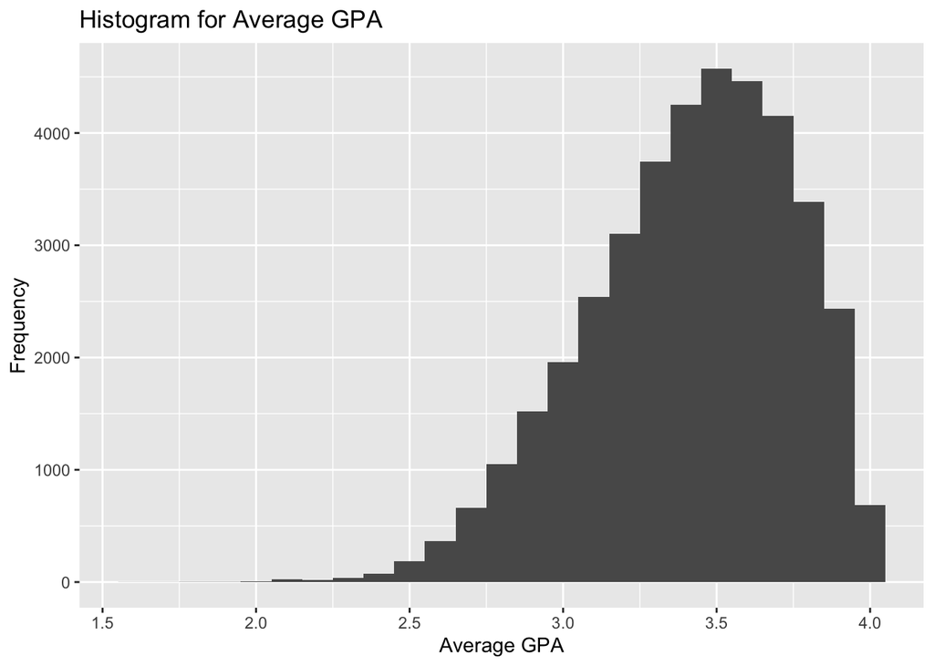

```r
# extract necessary numbers
total_courses <- nrow(uw_grades_df)
avg_gpa <-
  uw_grades_df |>
  pull(Average_GPA) |>
  mean(na.rm = TRUE)
avg_num_students <-
  uw_grades_df |>
  pull(Student_Count) |>
  mean(na.rm = TRUE)
min_course_number <-
  uw_grades_df |>
  pull(Course_Number_Num) |>
  min(na.rm = TRUE)
max_course_number <-
  uw_grades_df |>
  pull(Course_Number_Num) |>
  max(na.rm = TRUE)


# plot graphs
# histogram
ggplot(uw_grades_df) +
  geom_histogram(
    mapping = aes(x = Average_GPA),
    binwidth = 0.1
  )  +
  labs(
    title = "Histogram for Average GPA",
    x = "Average GPA",
    y = "Frequency",
  )
```

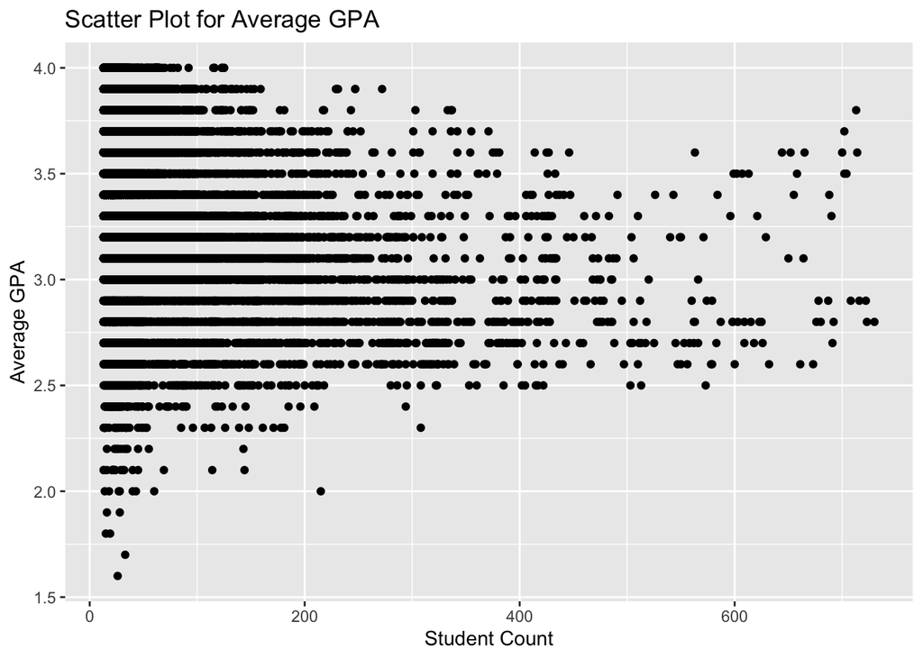

```r
# scatter plot
ggplot(uw_grades_df) +
  geom_point(
    mapping = aes(x = Student_Count, y = Average_GPA)
  ) +
  labs(
    title = "Scatter Plot for Average GPA",
    x = "Student Count",
    y = "Average GPA",
  )
```

Across all 39242 courses detailed in the dataset, the average GPA was 3.41 and the average number of students per class was 45. The lowest course number offered was 100, while the highest course number offered was 750. According to the plot “Histogram for Average GPA”, the most common GPA was right under 3.5, which happens to align with our finding of the overall average GPA. From mere visual observance, it seems the majority of students achieved a GPA in their class in the range 3.1-3.9. According to the plot “Scatter Plot for Average GPA”, it seems that most classes had class sizes under 300 students. Moreover, most of these classes achieved average GPAs between 2.6 and 3.6.

## Comparisons #1: MATH Program vs AMATH Program

### MATH Program

#### MATH Program Statistics

```r
# extract necessary numbers
math_grades_df <-
  uw_grades_df |>
  filter(Program_Abv == "MATH")
math_total_courses <- nrow(math_grades_df)
math_avg_gpa <-
  math_grades_df |>
  pull(Average_GPA) |>
  mean(na.rm = TRUE)
math_avg_num_students <-
  math_grades_df |>
  pull(Student_Count) |>
  mean(na.rm = TRUE)
math_min_course_number <-
  math_grades_df |>
  pull(Course_Number_Num) |>
  min(na.rm = TRUE)
math_max_course_number <-
  math_grades_df |>
  pull(Course_Number_Num) |>
  max(na.rm = TRUE)
```

#### MATH Program Plots

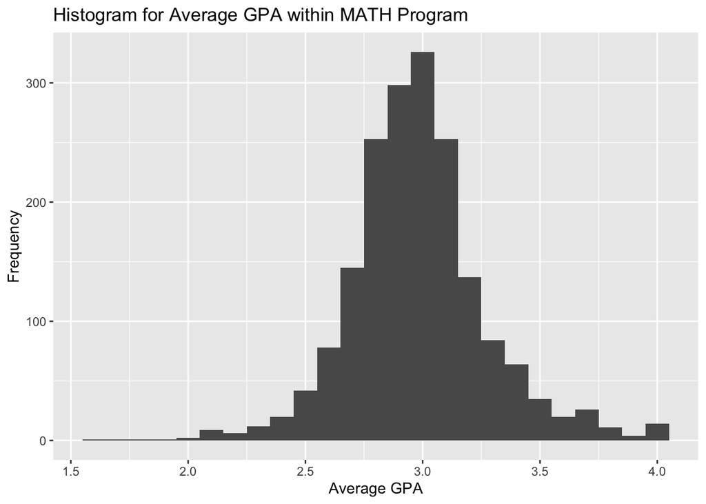

```r
# histogram
ggplot(math_grades_df) +
  geom_histogram(
    mapping = aes(x = Average_GPA),
    binwidth = 0.1
  )  +
  labs(
    title = "Histogram for Average GPA within MATH Program",
    x = "Average GPA",
    y = "Frequency",
  )
```

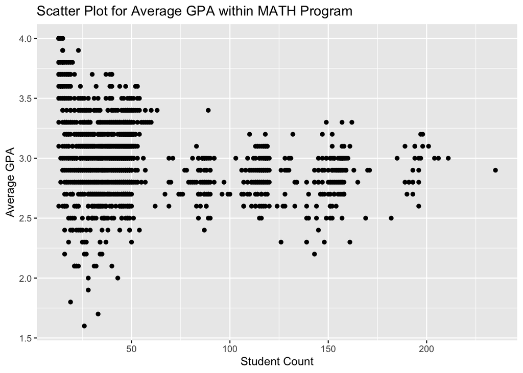

```r
# scatter plot
ggplot(math_grades_df) +
  geom_point(
    mapping = aes(x = Student_Count, y = Average_GPA)
  ) +
  labs(
    title = "Scatter Plot for Average GPA within MATH Program",
    x = "Student Count",
    y = "Average GPA",
  )
```

### AMATH Program

#### AMATH Program Statistics

```r
# extract necessary numbers
amath_grades_df <-
  uw_grades_df |>
  filter(Program_Abv == "AMATH")
amath_total_courses <- nrow(amath_grades_df)
amath_avg_gpa <-
  amath_grades_df |>
  pull(Average_GPA) |>
  mean(na.rm = TRUE)
amath_avg_num_students <-
  amath_grades_df |>
  pull(Student_Count) |>
  mean(na.rm = TRUE)
amath_min_course_number <-
  amath_grades_df |>
  pull(Course_Number_Num) |>
  min(na.rm = TRUE)
amath_max_course_number <-
  amath_grades_df |>
  pull(Course_Number_Num) |>
  max(na.rm = TRUE)
```

#### AMATH Program Plots

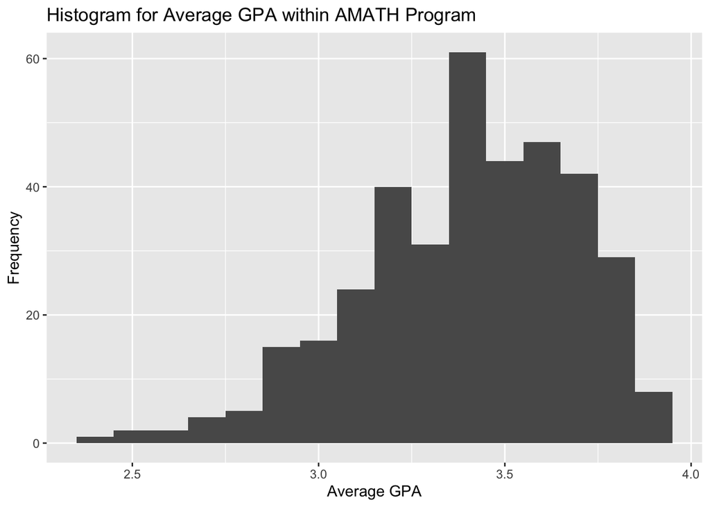

```r
# histogram
ggplot(amath_grades_df) +
  geom_histogram(
    mapping = aes(x = Average_GPA),
    binwidth = 0.1
  )  +
  labs(
    title = "Histogram for Average GPA within AMATH Program",
    x = "Average GPA",
    y = "Frequency",
  )
```

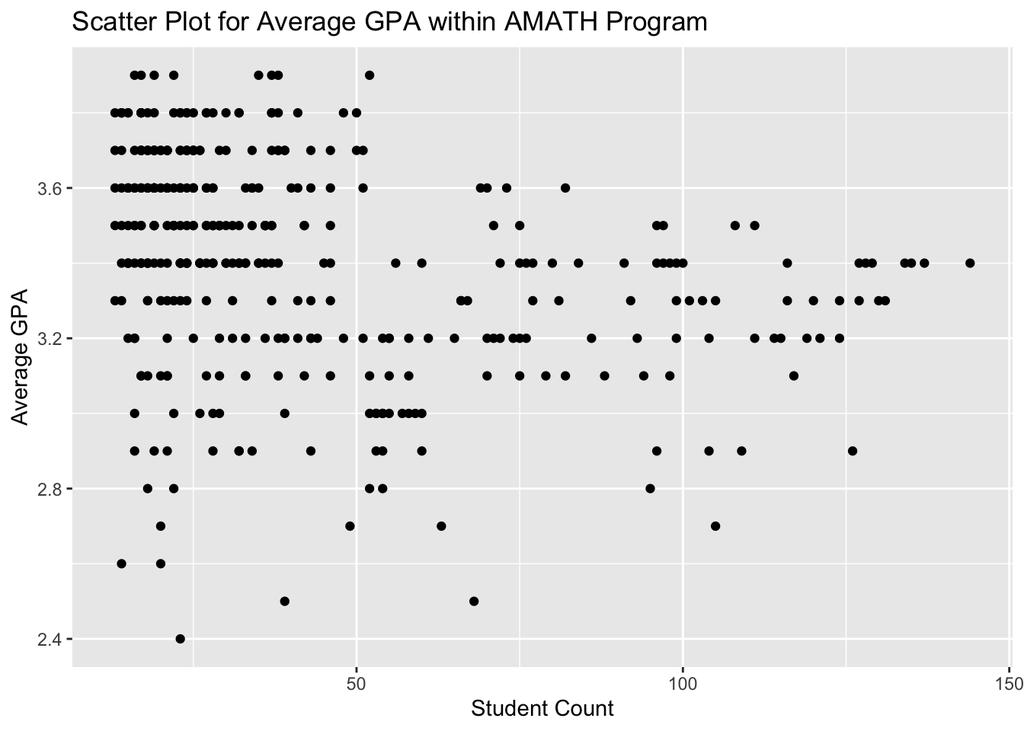

```r
# scatter plot
ggplot(amath_grades_df) +
  geom_point(
    mapping = aes(x = Student_Count, y = Average_GPA)
  ) +
  labs(
    title = "Scatter Plot for Average GPA within AMATH Program",
    x = "Student Count",
    y = "Average GPA",
  )
```

### Summary Paragraphs & Comparison

Within the MATH Program, the total number of courses offered was 1843. The average GPA across these classes was 2.98, while the average number of students per class was 58. The lowest course number offered was 100, while the highest course number offered was 583.

On the other hand, within the AMATH Program, the total number of courses offered was 371. The average GPA across these classes was 3.4, while the average number of students per class was 43. The lowest course number offered was 301, while the highest course number offered was 590.

When comparing the plots, these differences become even more apparent. For instance, the plot “Histogram for Average GPA within Math Program” shows that MATH GPAs crowded around 3.0, meanwhile the GPAs for the AMATH department are generally higher and crowd around 3.4 (as shown in the plot “Histogram for Average GPA within AMATH Program”). However, the MATH department was much larger than the AMATH department (1843 courses vs 371 courses), so this difference may be due simply to the fact that there is a lot more data for the MATH program.

The scatter plots show us more information about the sizes of classes in parallel to the GPAs achieved in these classes. The plot “Scatter Plot for Average GPA within MATH Program” shows that most MATH classes have a size under 50 students, though there seems to be distinct groups of classes with approximately 110-120 students and 145-160 students. Most MATH classes also end up with an average GPA between 2.5 and 3.5. On the other hand, the plot “Scatter Plot for Average GPA within AMATH Program” also seems to have most classes under 50 students. The average GPA for these classes mostly fall within the range 3.3-3.8. Moreover, the plot “Scatter Plot for Average GPA within AMATH Program” is much sparser than the plot “Scatter Plot for Average GPA within MATH Program”, owing to how the Math Program has many more courses.

Overall, the MATH Program is much larger than the AMATH Program. It also has generally lower average GPAs.

## Comparisons #2: Comparison of the Only Two Tagalog Professors JIEDSON R. DOMIGPE vs RICHARD ATIENZA

### Professor DOMIGPE

#### Professor DOMIGPE Statistics

```r
# extract necessary numbers
domigpe_grades_df <-
  uw_grades_df |>
  filter(Program_Abv == "TAGLG") |>
  filter(Primary_Instructor == "DOMIGPE, JIEDSON R.")
domigpe_total_courses <- nrow(domigpe_grades_df)
domigpe_avg_gpa <-
  domigpe_grades_df |>
  pull(Average_GPA) |>
  mean(na.rm = TRUE)
domigpe_avg_num_students <-
  domigpe_grades_df |>
  pull(Student_Count) |>
  mean(na.rm = TRUE)
domigpe_classes_taught <-
  domigpe_grades_df |>
  pull(Course_Title) |>
  unique()
```

#### Professor DOMIGPE Plots

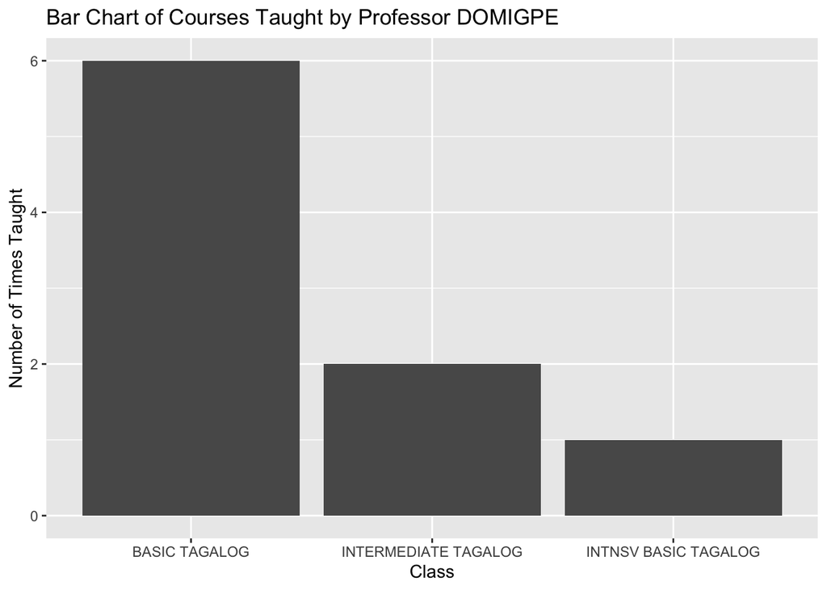

```r
# bar chart
ggplot(domigpe_grades_df) +
  geom_bar(
    mapping = aes(x = Course_Title),
  )  +
  labs(
    title = "Bar Chart of Courses Taught by Professor DOMIGPE",
    x = "Class",
    y = "Number of Times Taught",
  )
```

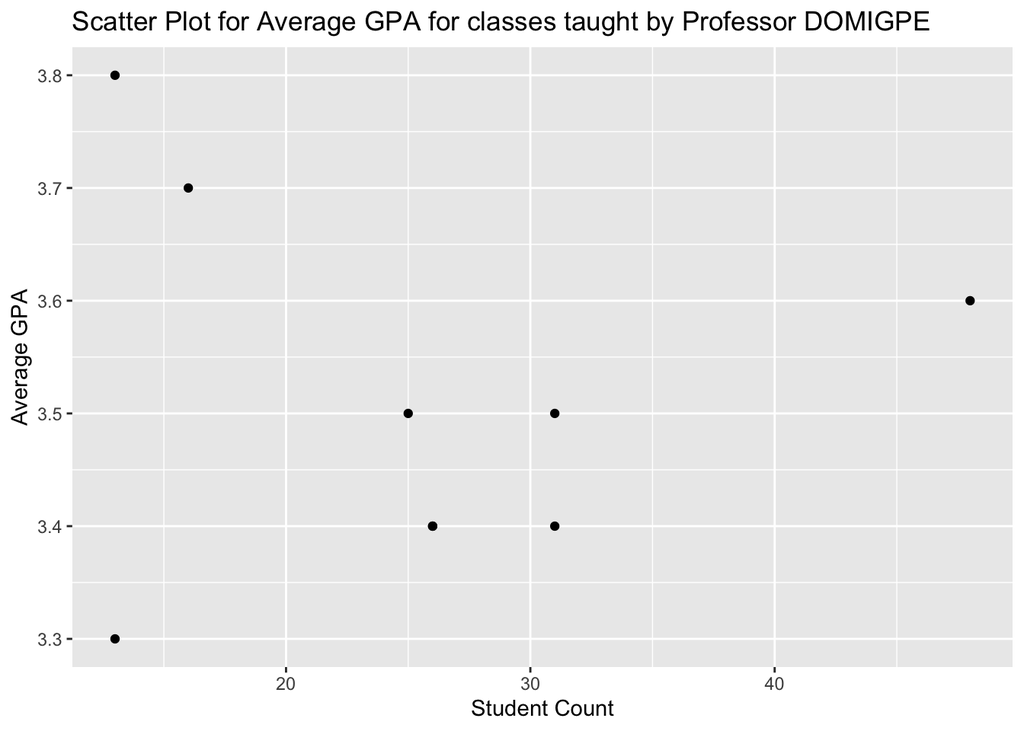

```r
# scatter plot
ggplot(domigpe_grades_df) +
  geom_point(
    mapping = aes(x = Student_Count, y = Average_GPA)
  ) +
  labs(
    title = "Scatter Plot for Average GPA for classes taught by Professor DOMIGPE",
    x = "Student Count",
    y = "Average GPA",
  )
```

### Professor ATIENZA Statistics

#### Professor ATIENZA Statistics

```r
# extract necessary numbers
atienza_grades_df <-
  uw_grades_df |>
  filter(Program_Abv == "TAGLG") |>
  filter(Primary_Instructor == "ATIENZA, RICHARD")
atienza_total_courses <- nrow(atienza_grades_df)
atienza_avg_gpa <-
  atienza_grades_df |>
  pull(Average_GPA) |>
  mean(na.rm = TRUE)
atienza_avg_num_students <-
  atienza_grades_df |>
  pull(Student_Count) |>
  mean(na.rm = TRUE)
atienza_classes_taught <-
  atienza_grades_df |>
  pull(Course_Title) |>
  unique()
```

#### Professor ATIENZA Plots

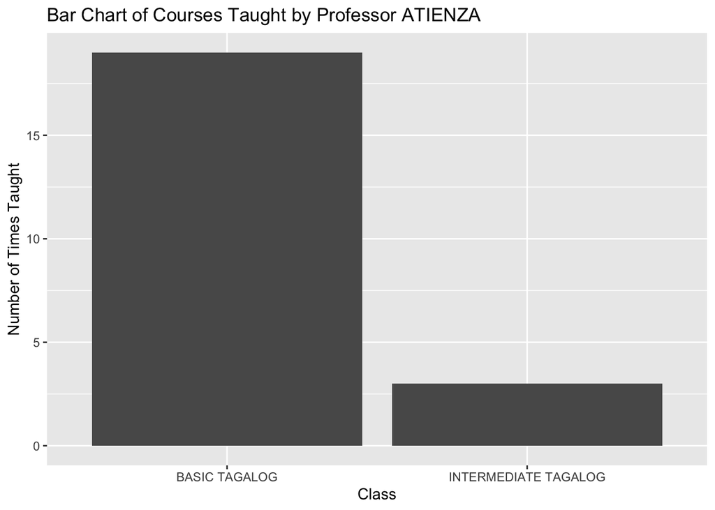

```r
# bar chart
ggplot(atienza_grades_df) +
  geom_bar(
    mapping = aes(x = Course_Title),
  )  +
  labs(
    title = "Bar Chart of Courses Taught by Professor ATIENZA",
    x = "Class",
    y = "Number of Times Taught",
  )
```

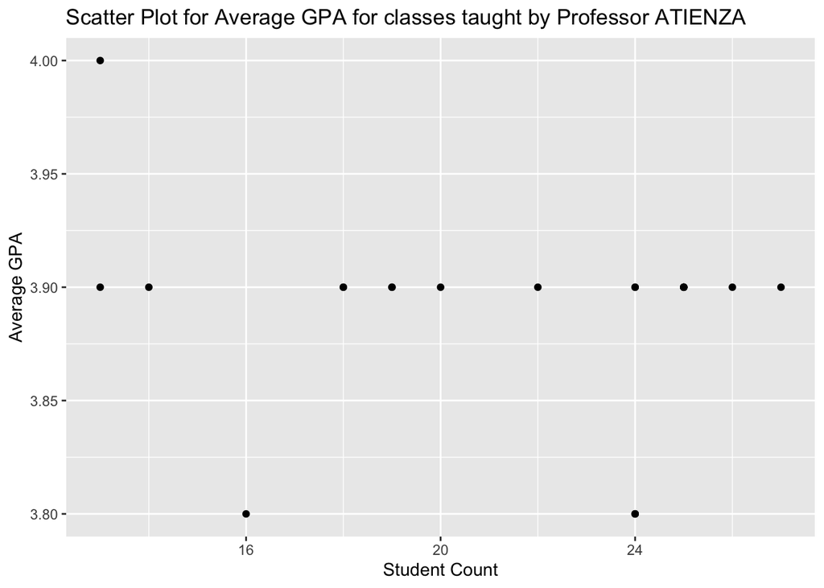

```r
# scatter plot
ggplot(atienza_grades_df) +
  geom_point(
    mapping = aes(x = Student_Count, y = Average_GPA)
  ) +
  labs(
    title = "Scatter Plot for Average GPA for classes taught by Professor ATIENZA",
    x = "Student Count",
    y = "Average GPA",
  )
```

### Summary Paragraphs & Comparison

Professor DOMIGPE taught a total of 9 classes. The average GPA achieved in their classes was 3.51 and the average number of students in their classes was 25. In total, Professor DOMIGPE taught a total of 3 different classes: BASIC TAGALOG, INTERMEDIATE TAGALOG, INTNSV BASIC TAGALOG.

Professor ATIENZA taught a total of 22 classes. The average GPA achieved in their classes was 3.89 and the average number of students in their classes was 21. In total, Professor ATIENZA taught a total of 2 different classes: BASIC TAGALOG, INTERMEDIATE TAGALOG.

Because there are relatively not many courses offered in the TAGALOG Program (31 classes total), the plots are not super informative and can’t be compared well to the plots of larger departments. But when comparing, the two professors in this department, some patterns can perhaps be uncovered.

On the other hand, the plots “Scatter Plot for Average GPA for classes taught by Professor DOMIGPE” and “Scatter Plot for Average GPA for classes taught by Professor ATIENZA” show that Professor DOMIGPE tends to offer a wider range of average GPAs in their courses (3.3-3.8) than Professor ATIENZA does (3.8-4.0). The courses taught by Professor DOMIGPE also tend to be bigger (13-48 students) than those taught by Professor ATIENZA (13-27).

Overall, Professor DOMIGPE taught a wider variety of TAGALOG classes, but Professor ATIENZA has taught more classes. Professor DOMIGPE also is a more difficult grader and tends to have larger classes than Professor ATIENZA.